# 12 Regular expressions

Authors

Affiliation

Vladimir Buskin

Catholic University of Eichstätt-Ingolstadt

Thomas Brunner

Catholic University of Eichstätt-Ingolstadt

## 12.1 Preparation

**Script**

You can find the full R script associated with this unit [here](https://osf.io/uhdns).

## 12.2 Suggested reading

> Lange and Leuckert (2020): Chapter 3.7

> [Detailed cheatsheet](https://images.datacamp.com/image/upload/v1665049611/Marketing/Blog/Regular_Expressions_Cheat_Sheet.pdf) (DataCamp)

## 12.3 Regular expressions

**Regular expressions** (or ‘regex’) help us find more complex patterns in strings of text. Suppose we are interested in finding all inflectional forms of the lemma PROVIDE in a corpus, i.e., *provide, provides, providing* and *provided*. Insteading of searching for all forms individually, we can construct a regular expression of the form

$$\text{provid(e(s)? | ing | ed)}$$
which can be read as

> ‘Match the sequence of letters <provid> as well as when it is followed by the groups of letters <es> or <ing> or <ed>. Also make the <s> in <es> optional.’

Notice how optionality is signified by the `?` operator and alternatives by `|`.

To activate regular expression in a `kwic()` query, the `valuetype` argument has to be set to `"regex"`:

```r
# Load library and corpus
library(quanteda)
ICE_GB <- readRDS("ICE_GB.RDS")

# Perform query
kwic_provide <- kwic(ICE_GB,
                     "provid(e(s)?|ing|ed)",
                     valuetype = "regex",
                     window = 20)
```

```r
table(kwic_provide$keyword)
```

```
     provide     provided     Provided    Provident providential     provider
         165          118            5            1            1            1
   providers     provides    providing    Providing
           3           72           52            1
```

There are two ways to handle the output:

1. **Refine the search expression** further to only match those cases of interest.
2. Manually **sort out irrelevant cases** during qualitative annotation in a spreadsheet software.

As a rule of thumb, you should consider improving your search expression if you obtain hundreds or even thousands of false hits. Should there be only few false positives, it’s usually easier to simply mark them as “irrelevant” in your spreadsheet. A full workflow is demonstrated in unit 13. Data annotation.

## 12.4 A RegEx Cheatsheet

### 12.4.1 Basic functions

| **Command** | **Definition** | **Example** | **Finds** |
| --- | --- | --- | --- |
|  |  | `python` | *python* |
| `.` | Any character | `.ython` | *aython, bython…* |

### 12.4.2 Character classes and alternatives

| **Command** | **Definition** | **Example** | **Finds** |
| --- | --- | --- | --- |
| `[abc]` | Class of characters | `[jp]ython` | *jython, python* |
| `[^pP]` | Excluded class of characters | `[^pP]ython` | everything but *python, Python* |
| `(...\|...)` | Alternatives linked by logical operator `or` | `P(ython\|eter)` | *Python, Peter* |

### 12.4.3 Quantifiers

| **Command** | **Definition** | **Example** | **Finds** |
| --- | --- | --- | --- |
| `?` | One or zero instances of the preceding symbol | `Py?thon` | *Python, Pthon* |
| `*` | No matter how many times — also zero | `Py*thon` | *Python, Pthon, Pyyyython…* |
|  |  | `P[Yy]*thon` | *Python, Pthon, PyYYython…* |
| `+` | No matter how many times but at least once | `Py+thon` | *Python, Pyyython, Pyyyython* |
| `{1,3}` | `{min, max}` | `Py{1,3}thon` | *Python, Pyython, Pyyython* |

### 12.4.4 Pre-defined character classes

**Note**

The double backslashes (`\\`) shown here are specific to the `quanteda` R package. In most other programming languages including Python, you only need a single backslash (e.g., `\w`, `\d`, `\s`). This double-escaping is an R-specific requirement due to how R handles string literals.

| **Command** | **Definition** | **Example** | **Finds** |
| --- | --- | --- | --- |
| `\\w` | All alphanumeric characters (A-Z, a-z, 0-9) | `\\w+ing` | *walking*, *running*, *42ing* |
| `\\W` | All non-alphanumeric characters | `hello\\W+world` | *hello world*, *hello!!!world* |
| `\\d` | All decimal numbers (0-9) | `\\d{3}-\\d{4}` | *555-1234*, *867-5309* |
| `\\D` | Everything which is not a decimal number | `\\D+` | *Hello!*, *Python_code* |
| `\\s` | Empty space | `word\\s+word` | *word word* |
| `\\b` | Word boundary | `\\bpython\\b` | Matches *python* as a whole word |

## 12.5 Querying parsed corpora

The range of linguistic patterns to be matched can be extended further if the corpus contains additional metadata, such as the part of speech (POS) of a token. POS-tagged corpora open up the option of looking for more abstract patterns, such as all instances of the verb *eat* that are followed by a pronoun or noun:

```r
# Load library and corpus
ICE_GB_POS <- readRDS("ICE_GB_POS.RDS")

# Perform query
kwic_provide_POS2 <- kwic(ICE_GB_POS,
                     phrase("\\b(ate|eat(s|ing|en)?)_VERB\\b _(PRON|NOUN)"),
                     valuetype = "regex",
                     window = 5)

head(kwic_provide_POS2)
```

| docname | from | to | pre | keyword | post | pattern |
| --- | --- | --- | --- | --- | --- | --- |
| S1A-009.txt | 1198 | 1199 | I_PRON must_AUX < , > | eat_VERB them_PRON | < ICE-GB:S1A-009 #71 : 1 | \b(ate\|eat(s\|ing\|en)?)_VERB\b _(PRON\|NOUN) |
| S1A-010.txt | 958 | 959 | to < , > actually_ADV | eat_VERB it_PRON | for_ADP one_NOUN ' s_PART own_ADJ | \b(ate\|eat(s\|ing\|en)?)_VERB\b _(PRON\|NOUN) |
| S1A-011.txt | 3245 | 3246 | : A > I_PRON have_AUX | eaten_VERB my_PRON | way_NOUN round_ADP the_DET Yorkshire_PROPN Dales_PROPN | \b(ate\|eat(s\|ing\|en)?)_VERB\b _(PRON\|NOUN) |
| S1A-011.txt | 4159 | 4160 | I_PRON ended_VERB up_ADP uhm_NOUN just_ADV | eating_VERB sort_NOUN | of_ADP_ADP lumps_NOUN of chicken_NOUN and_CCONJ | \b(ate\|eat(s\|ing\|en)?)_VERB\b _(PRON\|NOUN) |
| S1A-018.txt | 455 | 456 | order_VERB on_ADPe_NUM first_ADJ and_CCONJ_CCONJ then_ADV_ADV | eat_VERB it_PRON | and then sort_ADV of_ADV carry_VERB | \b(ate\|eat(s\|ing\|en)?)_VERB\b _(PRON\|NOUN) |
| S1A-019.txt | 1038 | 1039 | A > and_CCONJ everybody_PRON was_AUX | eating_VERB something_PRON | < ICE-GB:S1A-019 #76 : 1 | \b(ate\|eat(s\|ing\|en)?)_VERB\b _(PRON\|NOUN) |

One R package that supplies functions for tokenisation, POS-tagging and even dependency parsing for dozens of languages is `udpipe`. They all rely on one common set of tags known as **Universal Dependencies**, which are listed here:

**Universial dependencies – Tagset**

Cf. https://universaldependencies.org/u/pos/.

| POS Tag | Description |
| --- | --- |
| ADJ | Adjective: describes a noun (e.g., *big*, *old*, *green*, *first*) |
| ADP | Adposition: prepositions and postpositions (e.g., *in*, *to*, *over*) |
| ADV | Adverb: modifies verbs, adjectives, or other adverbs (e.g., *quickly*, *very*) |
| AUX | Auxiliary: helps form verb tenses, moods, or voices (e.g., *is*, *have*, *will*) |
| CCONJ | Coordinating conjunction: links words, phrases, or clauses (e.g., *and*, *or*, *but*) |
| DET | Determiner: introduces nouns (e.g., *the*, *a*, *some*, *my*) |
| INTJ | Interjection: expresses emotion or reaction (e.g., *oh*, *wow*, *hello*) |
| NOUN | Noun: person, place, thing, or concept (e.g., *cat*, *city*, *idea*) |
| NUM | Numeral: expresses a number or ranking (e.g., *one*, *two*, *second*) |
| PART | Particle: adds meaning without being an independent word class (e.g., *not*, *to* as in *to run*) |
| PRON | Pronoun: replaces nouns (e.g., *he*, *she*, *they*, *it*) |
| PROPN | Proper noun: names specific entities (e.g., *London*, *Vladimir*) |
| PUNCT | Punctuation: marks boundaries in text (*.* , *!* *?*) |
| SCONJ | Subordinating conjunction: links clauses, often indicating dependency (e.g., *if*, *because*, *although*) |
| SYM | Symbol: non-alphanumeric symbol (e.g., *%*, *&*, *#*) |
| VERB | Verb: action or state (e.g., *run*, *be*, *have*) |
| X | Other: used when a word doesn’t fit into other categories |

## 12.6 Working with other corpora

Some corpus platforms such as [BNCweb](https://bncweb.lancs.ac.uk), [CQPweb](https://cqpweb.lancs.ac.uk) or our local KU corpora[^1] support a specialised query syntax known as **CQP** (**C**orpus **Q**uery **P**rocessor), which enables users to query for strings with specific meta-attributes (text category, age, gender etc.).

<sup>1</sup> Note that the corpus platform of the Catholic University of Eichstätt-Ingolstadt, which was set up by Dr. Thomas Brunner, is only accessible to students or staff via the local **eduroam** network or a **VPN client** which holds their credentials.

### 12.6.1 Basic use

Once signed in on any of these platforms, the user interface will generally follow this layout:

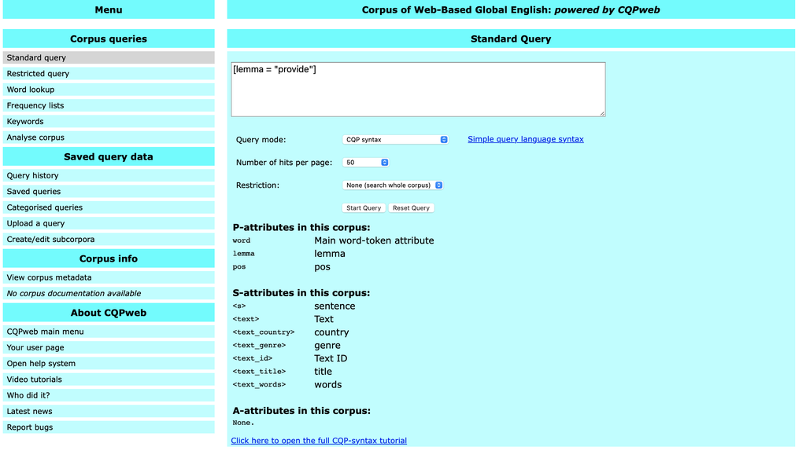

CQP query of PROVIDE in the GloWbE corpus

- To select a different corpus, navigate to `CQPweb main menu` under **About CQPweb** in the left menu bar.
- To restrict search results to specific parts of the corpus, select `Restricted query` and choose the relevant text categories, varieties, etc.

You can now enter a search expression into the white box using the following pattern:

```r
[attribute = "property"]
```

For example, to retrieve all inflectional forms[^2] of the verb *provide*, enter:

<sup>2</sup> Some corpora do not support the `lemma` attribute and require manual listing of all inflectional forms via regular expressions, such as `[word = "provid(e(s)?|d|ing)"]` for *provide*.

```r
[lemma = "provide"]
```

To search for a word with a specific part-of-speech (POS) tag – such as **like** used as a preposition – use:

```r
[word = "like" & pos = "ii"]
```

For a full list of POS-tags, refer to:

- [CLAWS5](https://ucrel.lancs.ac.uk/bnc2/bnc2guide.htm#tagset) (for **BNC**)
- [CLAWS7](https://ucrel.lancs.ac.uk/claws7tags.html) (for **COCA** and **GloWbE**)

**Note**

```r
[word = ".+" & pos = "nn"][word = ".+" & pos = "io"]
```

Regular expressions also allow you to match multiple POS-tags, such as all noun categories (`nn`, `nn1`, `nn2`, `nna`, etc.) or all prepositions (`if`, `ii`, `io`). The search term below generalises the previous example, making it more inclusive:

```r
[word = ".+" & pos = "n.+"][word = ".+" & pos = "i.+"]
```

However, be cautious with overly broad search patterns, as they might return (nearly) the entire corpus! The last one yields 22,294,282 matches.

### 12.6.2 Exporting and importing your results

To export your KWIC-hits, select `Download` in the top-right corner and specify your output options (e.g., the size of the search window or the speaker metadata). While you can immediately read the downloaded `concordance.txt` file into R, it’s advisable to first perform some **manual clean-up** in spreadsheet software (e.g., MS Excel). This ensures all columns and rows are complete and properly formatted.

To do this in Excel:

1. Navigate to `File > Import > Text file`.
2. Select your file and choose `Delimited`.
3. Click Next, select `Tab` as the delimiter, then click `Next > Finish`.

Make sure to **save your file**, ideally with the extension `.xlsx`.

From here, please refer to the unit Import/export data for further steps.

## 12.7 Exercises

**Solutions**

You can find the solutions to the exercises [here](https://osf.io/xaumr).

**Exercise 12.1** How could you refine the search expression for PROVIDE `"provid(e(s)?|ing|ed)"` to get rid of the irrelevant cases?

**Exercise 12.2** Write elegant regular expressions which find all inflectional forms of the following verbs:

- *accept*
- *attach*
- *swim*
- *know*
- *forget*

**Exercise 12.3** Find all nouns ending in *-er*.

**Exercise 12.4** Find all four-digit numbers.

**Exercise 12.5** Find all verbs that are followed by a preposition.

Lange, Claudia, and Sven Leuckert. 2020. *Corpus Linguistics for World Englishes: A Guide for Research*. New York: Taylor; Francis.